# Soal Latihan Pertemuan 4 - MPDW

Farik Firsteadi Haristiyanto

2023-09-21

## White Noise

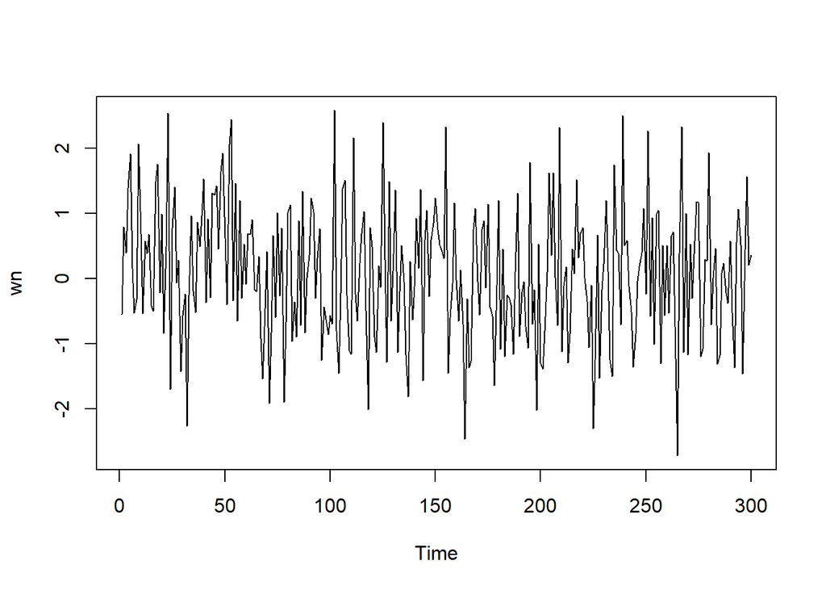

```r
wn <- rnorm(300)
ts.plot(wn)
```

## Pembangkitan Proses MA(2)

Akan dicoba membangkitkan proses MA sederhana, yaitu MA(2) dengan $\theta_1 = 0.4$ dan $\theta_2 = 0.6$ sebanyak 300 observasi dan $c=0$. Karena diperlukan satu nilai awal untuk $e_{t-1}$ dan $e_{t-2}$, masukkan nilai pertama white noise sebagai nilai awal tersebut.

```r
set.seed(015)
ma2 <- wn[c(1,2)]
```

Nilai-nilai selanjutnya dapat dicari melalui loop. Bentuk loop dapat dilihat dari rumus MA(2) yang hendak dibangkitkan:

$$y_t =
e_t+0.4e_{t-1}+0.6e_{t-2}$$

### Cara Manual

```r
for(i in 3:300){
   ma2[i] <- wn[i] + 0.4 * wn[i - 1] + 0.6 * wn[i - 2]
}
ma2
```

```
##   [1] -0.54224840  0.78977637  0.39359630  2.02309329  2.71515625  1.76136485
##   [7]  0.69240635 -0.43100290  1.62909838  1.32579536  0.97921657  0.77186553
##  [13]  0.29775736  1.18201069  0.09732239 -0.25292284  1.04448692  2.05235731
##  [19]  1.38509801  1.96246065 -0.56461926  0.75899810  2.24114106 -0.38068100
##  [25]  1.62740547  0.69815763  0.96642847  1.09798329 -1.34360661 -0.95828688
##  [31] -1.31168351 -2.69304922 -1.29583494 -0.49183908  0.04882392 -0.01716073
##  [37]  0.54955689  0.53042122  1.68587034  2.20934534  0.82065156  1.68082628
##  [43] -0.14501691  1.74104476  1.63297329  2.72249142  1.79497025  2.67977444
##  [49]  2.85761324  2.38102671  1.01374705  2.27617008  3.03257751  1.87522045
##  [55]  2.80000322 -0.26530192  1.82446245 -0.20725917  1.13127156 -0.04599917
##  [61]  0.97629346  0.91168577  1.59184323  0.60362952  0.27524420  0.15965959
##  [67] -0.89662582 -1.69500471 -1.62526216 -0.69179313 -2.02485936 -1.34341270
##  [73] -0.81373229 -0.82123522  1.17828231 -0.21035499  1.28201507 -1.74157213
##  [79] -0.96161555 -0.39223484  1.13651409  0.10306943 -0.05879962 -1.61503379
##  [85]  0.31974659 -0.89645025  1.59218941 -0.72366398  0.48215100 -0.13671152
```

[output cut: 35 more lines]

### Fungsi arima.sim

```r
set.seed(015)
ma2 <- arima.sim(list(order=c(0,0,2), ma=c(0.4,0.6)), n=300)
ma2
```

```
## Time Series:
## Start = 1
## End = 300
## Frequency = 1
##   [1]  0.54812344  1.86002316  0.64312441 -0.52186041 -0.18655635  0.34665700
##   [7]  0.31785977 -0.47338633  0.34573677 -0.66797661  0.53256869 -1.39555136
##  [13]  1.06150627 -0.16556869  0.85324433  0.02158507 -1.16696551 -0.96721922
##  [19]  0.46569321  1.65014480  0.98709236  0.24738601  0.59364668  0.57157624
##  [25]  1.51262112 -0.12861203  0.49428341  0.62910324  0.09584812  0.36384519
##  [31]  1.17466835  1.33565801  2.13746978  1.30654820  0.52617870  1.21729971
##  [37] -0.37171326 -0.95275802 -0.54870039  0.07620943  2.99079606  0.44175893
##  [43]  0.75859905  0.52788687 -0.82973296  1.86074713  0.65479779  2.15320349
##  [49]  1.48211399  1.85319609  0.57734476  2.19295338  0.93595312  0.28171567
##  [55] -0.80887136 -0.29254831  0.94566418  0.66426413  0.94853867 -0.37460641
##  [61] -0.58110711 -1.78890246 -2.35995946 -2.53343734 -1.68960786 -0.28703899
```

[output cut: 39 more lines]

## Karakteristik MA(2)

### Plot Time Series

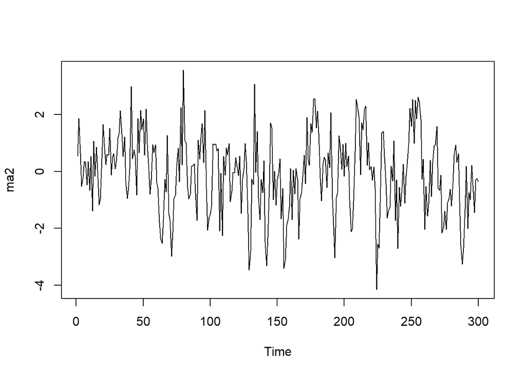

```r
ts.plot(ma2)
```

Berdasarkan plot time series, terlihat bahwa data MA(2) yang dibangkitkan stasioner dalam rataan

### Plot ACF

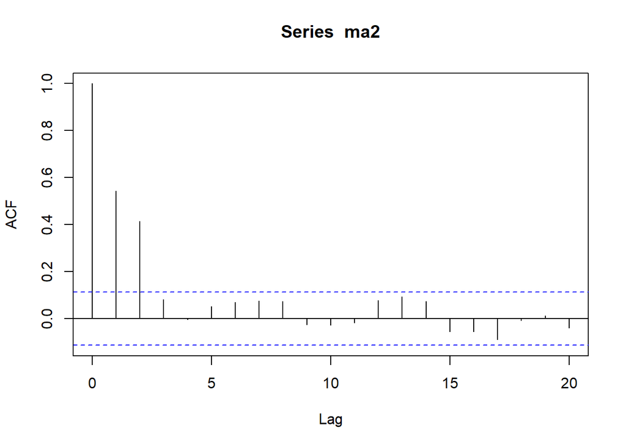

```r
acf(ma2,lag.max = 20)
```

### Plot PACF

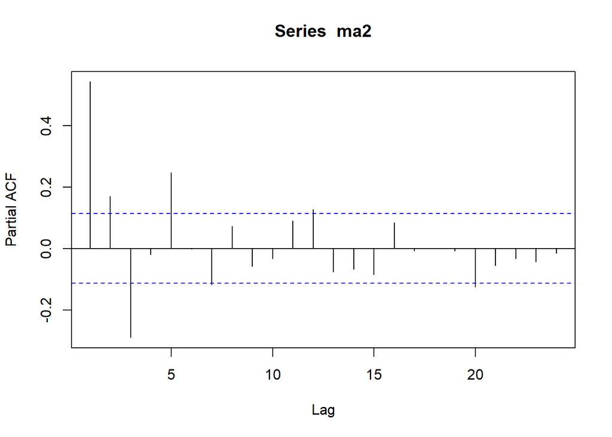

```r
pacf(ma2)
```

Berdasarkan plot PACF tersebut, terlihat bahwa plot PACF cenderung *tails off* dan membentuk gelombang sinus

### Plot EACF

```r
TSA::eacf(ma2)
```

```
## AR/MA
##   0 1 2 3 4 5 6 7 8 9 10 11 12 13
## 0 x x o o o o o o o o o  o  o  o
## 1 x x o o o o o o o o o  o  o  o
## 2 x x o x o o o o o o o  o  o  o
## 3 o x x x o o o o o o o  o  o  o
## 4 o x x x o o o o o o o  o  o  o
## 5 o x x o o x x o o o o  o  o  o
## 6 o x x x o o x o o o o  o  o  o
## 7 x o x x o x x o o o o  o  o  o
```

Berdasarkan pola segitiga nol pada plot EACF, terlihat bahwa segitiga nol berada pada ordo AR(0) dan ordo MA(2)

## Scatterplot Antar Peubah Lag

### Korelasi antara $Y_t$ dengan $Y_{t-1}$

```r
#Yt
yt_ma2 <- ma2[-1]
yt_ma2
```

```
##   [1]  1.86002316  0.64312441 -0.52186041 -0.18655635  0.34665700  0.31785977
##   [7] -0.47338633  0.34573677 -0.66797661  0.53256869 -1.39555136  1.06150627
##  [13] -0.16556869  0.85324433  0.02158507 -1.16696551 -0.96721922  0.46569321
##  [19]  1.65014480  0.98709236  0.24738601  0.59364668  0.57157624  1.51262112
##  [25] -0.12861203  0.49428341  0.62910324  0.09584812  0.36384519  1.17466835
##  [31]  1.33565801  2.13746978  1.30654820  0.52617870  1.21729971 -0.37171326
##  [37] -0.95275802 -0.54870039  0.07620943  2.99079606  0.44175893  0.75859905
##  [43]  0.52788687 -0.82973296  1.86074713  0.65479779  2.15320349  1.48211399
##  [49]  1.85319609  0.57734476  2.19295338  0.93595312  0.28171567 -0.80887136
##  [55] -0.29254831  0.94566418  0.66426413  0.94853867 -0.37460641 -0.58110711
##  [61] -1.78890246 -2.35995946 -2.53343734 -1.68960786 -0.28703899 -0.72302522
##  [67]  1.27076091 -1.47277432 -1.74210692 -2.99284487 -2.15380778 -0.95481880
##  [73] -0.82671505  0.16622221  0.82033406 -0.36479959  2.24931827  0.23006279
##  [79]  3.56047333  1.09018740  0.99714728 -0.56321763 -0.96370739 -0.80268365
##  [85]  0.18780347  0.18008899  0.26819074 -0.76011607 -1.71955616  1.11118312
```

[output cut: 35 more lines]

```r
#Yt-1
yt_1_ma2 <- ma2[-300]
yt_1_ma2
```

```
##   [1]  0.54812344  1.86002316  0.64312441 -0.52186041 -0.18655635  0.34665700
##   [7]  0.31785977 -0.47338633  0.34573677 -0.66797661  0.53256869 -1.39555136
##  [13]  1.06150627 -0.16556869  0.85324433  0.02158507 -1.16696551 -0.96721922
##  [19]  0.46569321  1.65014480  0.98709236  0.24738601  0.59364668  0.57157624
##  [25]  1.51262112 -0.12861203  0.49428341  0.62910324  0.09584812  0.36384519
##  [31]  1.17466835  1.33565801  2.13746978  1.30654820  0.52617870  1.21729971
##  [37] -0.37171326 -0.95275802 -0.54870039  0.07620943  2.99079606  0.44175893
##  [43]  0.75859905  0.52788687 -0.82973296  1.86074713  0.65479779  2.15320349
##  [49]  1.48211399  1.85319609  0.57734476  2.19295338  0.93595312  0.28171567
##  [55] -0.80887136 -0.29254831  0.94566418  0.66426413  0.94853867 -0.37460641
##  [61] -0.58110711 -1.78890246 -2.35995946 -2.53343734 -1.68960786 -0.28703899
##  [67] -0.72302522  1.27076091 -1.47277432 -1.74210692 -2.99284487 -2.15380778
##  [73] -0.95481880 -0.82671505  0.16622221  0.82033406 -0.36479959  2.24931827
##  [79]  0.23006279  3.56047333  1.09018740  0.99714728 -0.56321763 -0.96370739
##  [85] -0.80268365  0.18780347  0.18008899  0.26819074 -0.76011607 -1.71955616
```

[output cut: 35 more lines]

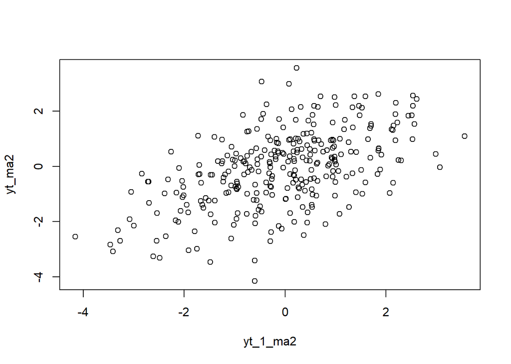

```r
plot(y=yt_ma2,x=yt_1_ma2)
```

Berdasarkan scatterplot tersebut, terlihat bahwa terdapat hubungan positif antara $Y_t$ dengan $Y_{t-1}$. Hal ini sesuai dengan teori yang ada

```r
cor(yt_ma2,yt_1_ma2)
```

```
## [1] 0.5426377
```

### Korelasi antara $Y_t$ dengan $Y_{t-2}$

```r
#Yt
yt_ma2.2 <- ma2[-c(1,2)]
yt_ma2.2
```

```
##   [1]  0.64312441 -0.52186041 -0.18655635  0.34665700  0.31785977 -0.47338633
##   [7]  0.34573677 -0.66797661  0.53256869 -1.39555136  1.06150627 -0.16556869
##  [13]  0.85324433  0.02158507 -1.16696551 -0.96721922  0.46569321  1.65014480
##  [19]  0.98709236  0.24738601  0.59364668  0.57157624  1.51262112 -0.12861203
##  [25]  0.49428341  0.62910324  0.09584812  0.36384519  1.17466835  1.33565801
##  [31]  2.13746978  1.30654820  0.52617870  1.21729971 -0.37171326 -0.95275802
##  [37] -0.54870039  0.07620943  2.99079606  0.44175893  0.75859905  0.52788687
##  [43] -0.82973296  1.86074713  0.65479779  2.15320349  1.48211399  1.85319609
##  [49]  0.57734476  2.19295338  0.93595312  0.28171567 -0.80887136 -0.29254831
##  [55]  0.94566418  0.66426413  0.94853867 -0.37460641 -0.58110711 -1.78890246
##  [61] -2.35995946 -2.53343734 -1.68960786 -0.28703899 -0.72302522  1.27076091
##  [67] -1.47277432 -1.74210692 -2.99284487 -2.15380778 -0.95481880 -0.82671505
##  [73]  0.16622221  0.82033406 -0.36479959  2.24931827  0.23006279  3.56047333
##  [79]  1.09018740  0.99714728 -0.56321763 -0.96370739 -0.80268365  0.18780347
##  [85]  0.18008899  0.26819074 -0.76011607 -1.71955616  1.11118312  0.42958895
```

[output cut: 35 more lines]

```r
#Yt-2
yt_2_ma2 <- ma2[-c(299,300)]
yt_2_ma2
```

```
##   [1]  0.54812344  1.86002316  0.64312441 -0.52186041 -0.18655635  0.34665700
##   [7]  0.31785977 -0.47338633  0.34573677 -0.66797661  0.53256869 -1.39555136
##  [13]  1.06150627 -0.16556869  0.85324433  0.02158507 -1.16696551 -0.96721922
##  [19]  0.46569321  1.65014480  0.98709236  0.24738601  0.59364668  0.57157624
##  [25]  1.51262112 -0.12861203  0.49428341  0.62910324  0.09584812  0.36384519
##  [31]  1.17466835  1.33565801  2.13746978  1.30654820  0.52617870  1.21729971
##  [37] -0.37171326 -0.95275802 -0.54870039  0.07620943  2.99079606  0.44175893
##  [43]  0.75859905  0.52788687 -0.82973296  1.86074713  0.65479779  2.15320349
##  [49]  1.48211399  1.85319609  0.57734476  2.19295338  0.93595312  0.28171567
##  [55] -0.80887136 -0.29254831  0.94566418  0.66426413  0.94853867 -0.37460641
##  [61] -0.58110711 -1.78890246 -2.35995946 -2.53343734 -1.68960786 -0.28703899
##  [67] -0.72302522  1.27076091 -1.47277432 -1.74210692 -2.99284487 -2.15380778
##  [73] -0.95481880 -0.82671505  0.16622221  0.82033406 -0.36479959  2.24931827
##  [79]  0.23006279  3.56047333  1.09018740  0.99714728 -0.56321763 -0.96370739
##  [85] -0.80268365  0.18780347  0.18008899  0.26819074 -0.76011607 -1.71955616
```

[output cut: 35 more lines]

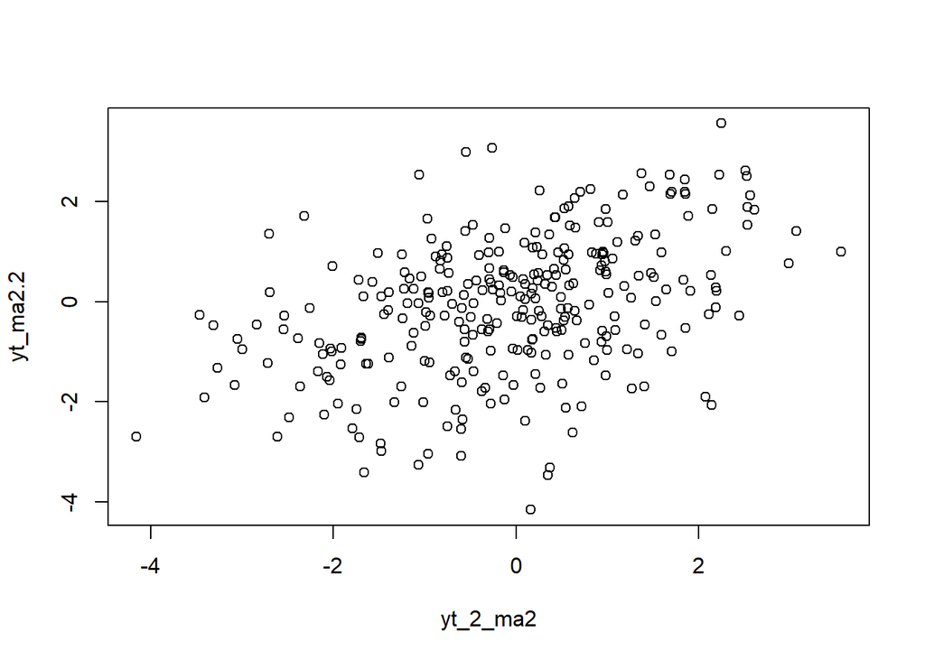

```r
plot(y=yt_ma2.2,x=yt_2_ma2)
```

Berdasarkan scatterplot tersebut, terlihat bahwa cenderung masih terdapat hubungan positif antara $Y_t$ dengan $Y_{t-2}$.

```r
cor(yt_ma2.2,yt_2_ma2)
```

```
## [1] 0.4160779
```

### Korelasi antara $Y_t$ dengan $Y_{t-3}$

```r
#Yt
yt_ma2.3 <- ma2[-c(1,2,3)]
yt_ma2.3
```

```
##   [1] -0.52186041 -0.18655635  0.34665700  0.31785977 -0.47338633  0.34573677
##   [7] -0.66797661  0.53256869 -1.39555136  1.06150627 -0.16556869  0.85324433
##  [13]  0.02158507 -1.16696551 -0.96721922  0.46569321  1.65014480  0.98709236
##  [19]  0.24738601  0.59364668  0.57157624  1.51262112 -0.12861203  0.49428341
##  [25]  0.62910324  0.09584812  0.36384519  1.17466835  1.33565801  2.13746978
##  [31]  1.30654820  0.52617870  1.21729971 -0.37171326 -0.95275802 -0.54870039
##  [37]  0.07620943  2.99079606  0.44175893  0.75859905  0.52788687 -0.82973296
##  [43]  1.86074713  0.65479779  2.15320349  1.48211399  1.85319609  0.57734476
##  [49]  2.19295338  0.93595312  0.28171567 -0.80887136 -0.29254831  0.94566418
##  [55]  0.66426413  0.94853867 -0.37460641 -0.58110711 -1.78890246 -2.35995946
##  [61] -2.53343734 -1.68960786 -0.28703899 -0.72302522  1.27076091 -1.47277432
##  [67] -1.74210692 -2.99284487 -2.15380778 -0.95481880 -0.82671505  0.16622221
##  [73]  0.82033406 -0.36479959  2.24931827  0.23006279  3.56047333  1.09018740
##  [79]  0.99714728 -0.56321763 -0.96370739 -0.80268365  0.18780347  0.18008899
##  [85]  0.26819074 -0.76011607 -1.71955616  1.11118312  0.42958895  1.18990179
```

[output cut: 35 more lines]

```r
#Yt-2
yt_3_ma2 <- ma2[-c(289,299,300)]
yt_3_ma2
```

```
##   [1]  0.54812344  1.86002316  0.64312441 -0.52186041 -0.18655635  0.34665700
##   [7]  0.31785977 -0.47338633  0.34573677 -0.66797661  0.53256869 -1.39555136
##  [13]  1.06150627 -0.16556869  0.85324433  0.02158507 -1.16696551 -0.96721922
##  [19]  0.46569321  1.65014480  0.98709236  0.24738601  0.59364668  0.57157624
##  [25]  1.51262112 -0.12861203  0.49428341  0.62910324  0.09584812  0.36384519
##  [31]  1.17466835  1.33565801  2.13746978  1.30654820  0.52617870  1.21729971
##  [37] -0.37171326 -0.95275802 -0.54870039  0.07620943  2.99079606  0.44175893
##  [43]  0.75859905  0.52788687 -0.82973296  1.86074713  0.65479779  2.15320349
##  [49]  1.48211399  1.85319609  0.57734476  2.19295338  0.93595312  0.28171567
##  [55] -0.80887136 -0.29254831  0.94566418  0.66426413  0.94853867 -0.37460641
##  [61] -0.58110711 -1.78890246 -2.35995946 -2.53343734 -1.68960786 -0.28703899
##  [67] -0.72302522  1.27076091 -1.47277432 -1.74210692 -2.99284487 -2.15380778
##  [73] -0.95481880 -0.82671505  0.16622221  0.82033406 -0.36479959  2.24931827
##  [79]  0.23006279  3.56047333  1.09018740  0.99714728 -0.56321763 -0.96370739
##  [85] -0.80268365  0.18780347  0.18008899  0.26819074 -0.76011607 -1.71955616
```

[output cut: 35 more lines]

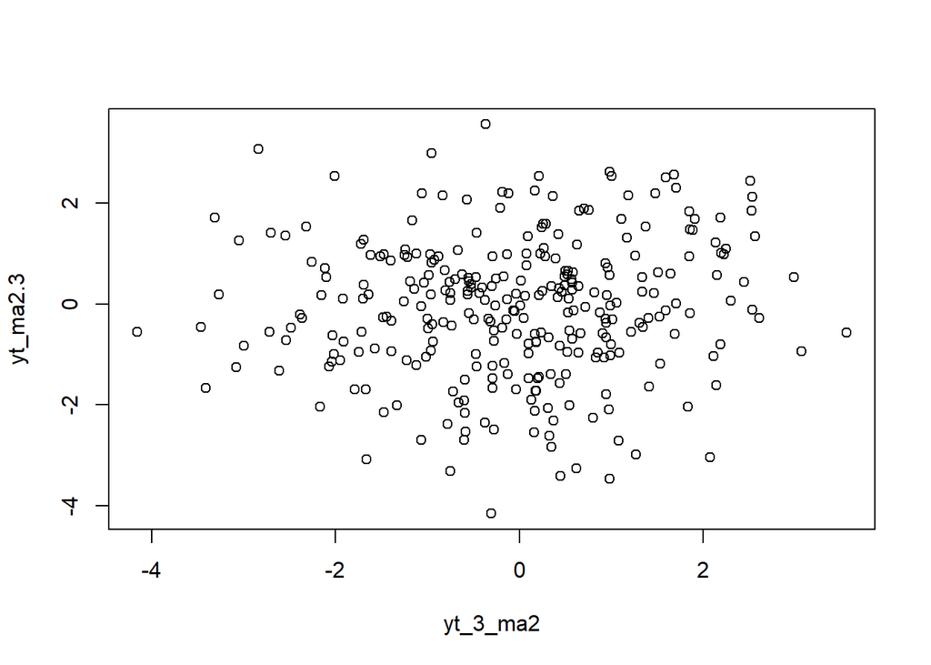

```r
plot(y=yt_ma2.3,x=yt_3_ma2)
```

Berdasarkan scatterplot tersebut, terlihat bahwa cenderung tidak terdapat hubungan antara $Y_t$ dengan $Y_{t-3}$.

```r
cor(yt_ma2.3,yt_3_ma2)
```

```
## [1] 0.07637478
```

### Perbandingan korelasi $Yt_t$ dengan $Y_{t-1}$, $Yt_t$ dengan $Y_{t-2}$, & $Yt_t$ dengan $Y_{t-3}$

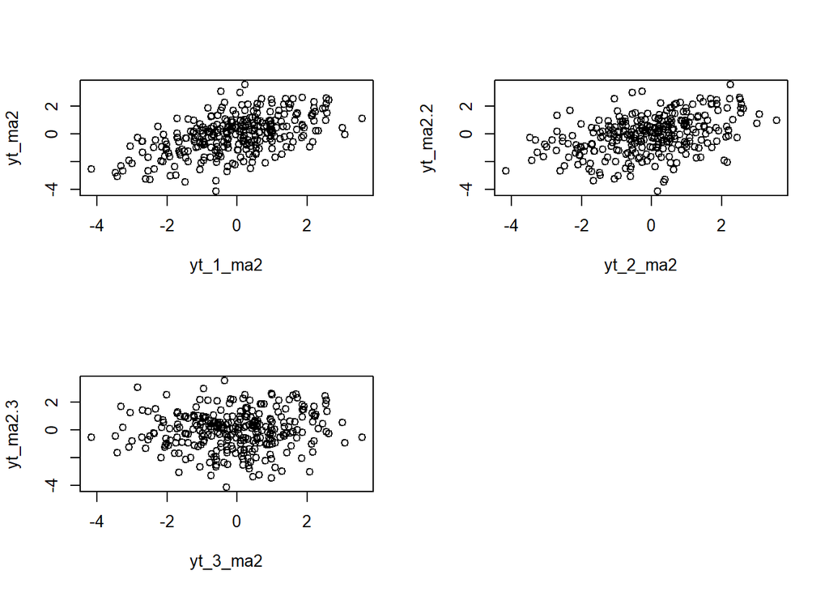

```r
par(mfrow=c(2,2))
plot(y=yt_ma2,x=yt_1_ma2)
plot(y=yt_ma2.2,x=yt_2_ma2)
plot(y=yt_ma2.3,x=yt_3_ma2)
```

## Pembangkitan Proses AR(2)

Akan dicoba membangkitkan proses AR paling sederhana, yaitu AR(2) dengan $\phi_1 = 0.5$ dan $\phi_2 = 0.2$ sebanyak 300 observasi dan $c=0$.

Nilai-nilai selanjutnya dapat dicari melalui *loop*. Bentuk loop dapat dilihat dari rumus AR(1) yang hendak dibangkitkan:

$$Y_t = e_t+0.5Y_{t-1}+0.2Y_{t-2}$$

### Cara Manual

```r
set.seed(015)
n<-length(wn)
n
```

```
## [1] 300
```

```r
ar2 <- c(2:n)
for (i in 3:n) {ar2[i]<-wn[i]+0.5*ar2[i-1]+0.2*ar2[i-2]}
ar2
```

```
##   [1]  2.000000000  3.000000000  2.303034801  3.139530950  3.948502381
##   [6]  2.763462120  1.648438019  1.058323094  2.929178976  2.365070537
##  [11]  1.229863172  1.661924520  1.468205463  1.747602798  0.757556474
##  [16]  0.230661262  1.756315471  2.679440405  1.480337017  2.269685506
##  [21]  0.595227093  1.248644622  3.287081037  0.196846735  1.535586140
##  [26]  2.211275046  1.349690232  1.397841649 -0.449205636 -0.504540476
##  [31] -0.579153780 -2.653013650 -1.690935610 -0.410953208 -0.731727916
##  [36] -0.969060049  0.239921972  0.420854437  1.223921223  2.222449716
##  [41]  0.986827612  1.850611692  0.834080174  2.096018897  2.497410904
##  [46]  3.092052602  2.501270133  3.512029341  4.183231448  3.418472947
##  [51]  2.153671625  3.818914128  4.784742092  2.818523805  3.834535143
##  [56]  1.830918520  2.885855371  1.510488875  1.861042627  1.154342580
##  [61]  1.639807612  1.733252875  2.099182292  1.228545177  0.833675265
##  [66]  1.002997697 -0.244312057 -1.455813436 -1.240800936 -0.497189391
##  [71] -2.408944660 -2.131071254 -0.882878568 -1.458370521  0.110140534
```

[output cut: 45 more lines]

### Fungsi arima.sim

```r
set.seed(015)
ar2 <- arima.sim(list(order=c(2,0,0), ar=c(0.5,0.2)), n=300)
ar2
```

```
## Time Series:
## Start = 1
## End = 300
## Frequency = 1
##   [1]  1.04557460  1.49228682  0.27458346  0.76194543  1.34291904  0.36116707
##   [7]  0.45386737  1.74956435  1.71823474  2.17519003  1.89971879  1.14398950
##  [13]  1.98451529  0.58085631 -0.62889318  0.16363358  0.67721866  2.85651456
##  [19]  0.57868024  0.52214328  1.63110692 -0.20837069  1.78154476  1.55710423
##  [25]  2.06915693  2.02959136  2.44780882  1.38933951  2.86186911  2.11799044
##  [31]  0.74282697  0.09604426  0.71675138  1.53456356  0.80000626  1.00551742
##  [37]  0.23508840 -0.27055175 -1.38487794 -2.23434122 -2.55449493 -2.05690894
##  [43] -0.99706591 -1.65017904  0.21699140 -1.74675349 -2.70689650 -3.02974857
##  [49] -2.55313069 -1.84241324 -1.97646227 -0.99670086  0.10946371 -1.12665830
##  [55]  1.49883790  0.52727034  2.89843828  1.70893657  0.96857656  0.35653170
##  [61] -0.12456105 -0.31331461  0.43309546  0.28151207  0.07571598 -0.68186836
```

[output cut: 39 more lines]

## Karakteristik AR(2)

### Plot Time Series

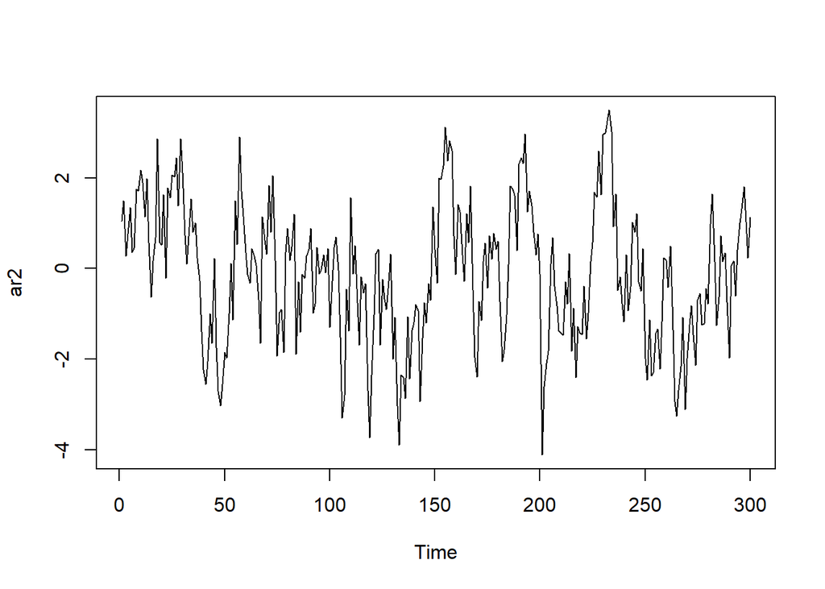

```r
ts.plot(ar2)
```

Berdasarkan plot time series tersebut terlihat bahwa data cenderung stasioner pada rataan

### Plot ACF

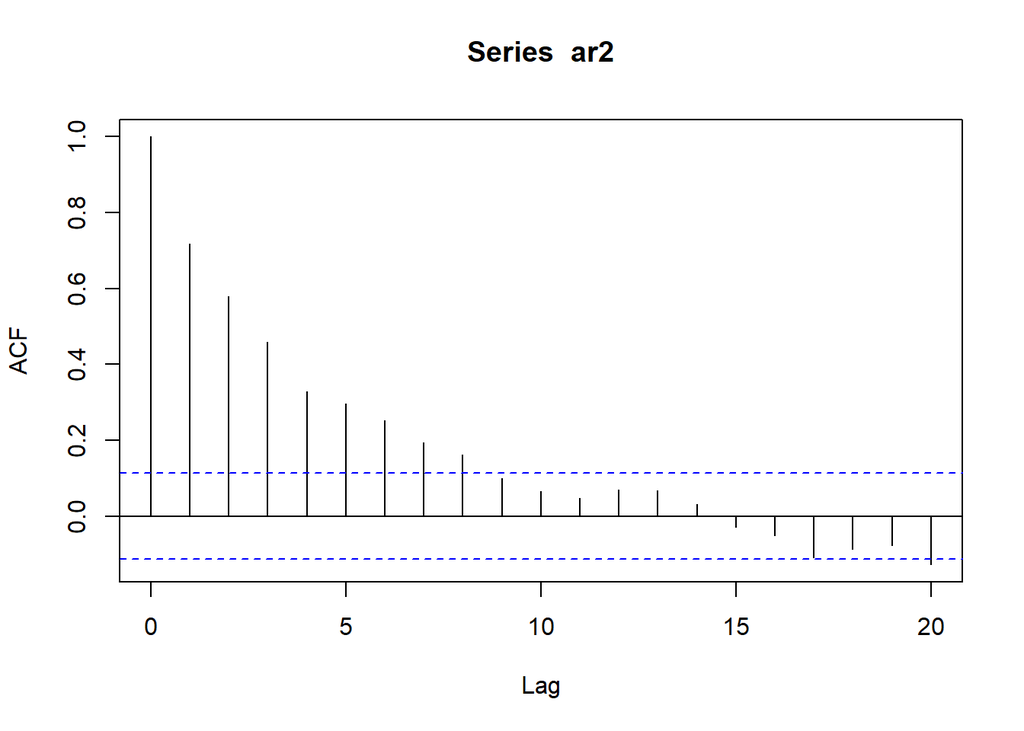

```r
acf(ar2,lag.max = 20)
```

### Plot PACF

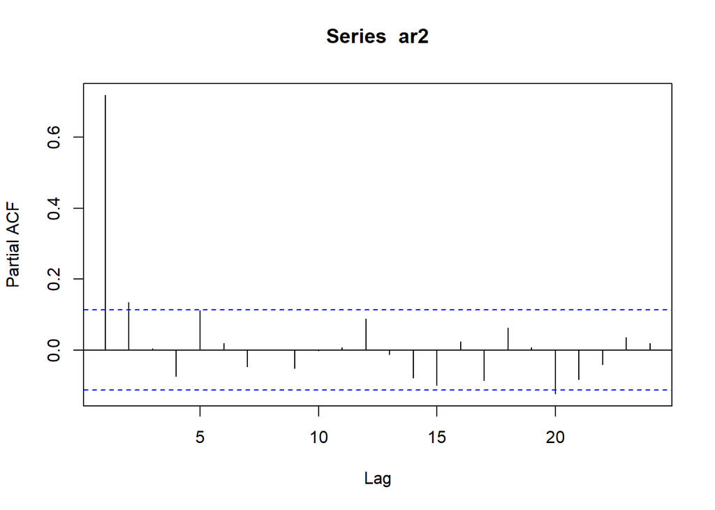

```r
pacf(ar2)
```

### Plot EACF

```r
TSA::eacf(ar2)
```

```
## AR/MA
##   0 1 2 3 4 5 6 7 8 9 10 11 12 13
## 0 x x x x x x x x o o o  o  o  o
## 1 x o o x o o o o o o o  o  o  o
## 2 o o o x o o o o o o o  o  o  o
## 3 o x o o o o o o o o o  o  o  o
## 4 x x x o o o o o o o o  o  o  o
## 5 x x o x o o o o o o o  o  o  o
## 6 x x o x x o o o o o o  o  o  o
## 7 o x o x x o o o o o o  o  o  o
```

Berdasarkan pola segitiga nol pada plot EACF, terlihat bahwa segitiga nol berada pada ordo AR(2) dan ordo MA(0)

## Scatterplot Antar Peubah Lag

### Korelasi antara $Y_t$ dengan $Y_{t-1}$

```r
#Yt
yt_ar2 <- ar2[-1]
yt_ar2
```

```
##   [1]  1.49228682  0.27458346  0.76194543  1.34291904  0.36116707  0.45386737
##   [7]  1.74956435  1.71823474  2.17519003  1.89971879  1.14398950  1.98451529
##  [13]  0.58085631 -0.62889318  0.16363358  0.67721866  2.85651456  0.57868024
##  [19]  0.52214328  1.63110692 -0.20837069  1.78154476  1.55710423  2.06915693
##  [25]  2.02959136  2.44780882  1.38933951  2.86186911  2.11799044  0.74282697
##  [31]  0.09604426  0.71675138  1.53456356  0.80000626  1.00551742  0.23508840
##  [37] -0.27055175 -1.38487794 -2.23434122 -2.55449493 -2.05690894 -0.99706591
##  [43] -1.65017904  0.21699140 -1.74675349 -2.70689650 -3.02974857 -2.55313069
##  [49] -1.84241324 -1.97646227 -0.99670086  0.10946371 -1.12665830  1.49883790
##  [55]  0.52727034  2.89843828  1.70893657  0.96857656  0.35653170 -0.12456105
##  [61] -0.31331461  0.43309546  0.28151207  0.07571598 -0.68186836 -1.64394015
##  [67]  1.14571630  0.62292455  0.31652953  1.83473863  0.81059577  2.05688992
##  [73]  0.18850850 -1.93185497 -0.96825153 -0.90015343 -1.85180695  0.35940435
##  [79]  0.88844947  0.18133223  0.47365132  1.19447968 -1.89543774 -0.29275010
##  [85] -1.39881945 -0.13438300 -0.20812267  0.27512639  0.42966537  0.88168497
```

[output cut: 35 more lines]

```r
#Yt-1
yt_1_ar2 <- ar2[-300]
yt_1_ar2
```

```
##   [1]  1.04557460  1.49228682  0.27458346  0.76194543  1.34291904  0.36116707
##   [7]  0.45386737  1.74956435  1.71823474  2.17519003  1.89971879  1.14398950
##  [13]  1.98451529  0.58085631 -0.62889318  0.16363358  0.67721866  2.85651456
##  [19]  0.57868024  0.52214328  1.63110692 -0.20837069  1.78154476  1.55710423
##  [25]  2.06915693  2.02959136  2.44780882  1.38933951  2.86186911  2.11799044
##  [31]  0.74282697  0.09604426  0.71675138  1.53456356  0.80000626  1.00551742
##  [37]  0.23508840 -0.27055175 -1.38487794 -2.23434122 -2.55449493 -2.05690894
##  [43] -0.99706591 -1.65017904  0.21699140 -1.74675349 -2.70689650 -3.02974857
##  [49] -2.55313069 -1.84241324 -1.97646227 -0.99670086  0.10946371 -1.12665830
##  [55]  1.49883790  0.52727034  2.89843828  1.70893657  0.96857656  0.35653170
##  [61] -0.12456105 -0.31331461  0.43309546  0.28151207  0.07571598 -0.68186836
##  [67] -1.64394015  1.14571630  0.62292455  0.31652953  1.83473863  0.81059577
##  [73]  2.05688992  0.18850850 -1.93185497 -0.96825153 -0.90015343 -1.85180695
##  [79]  0.35940435  0.88844947  0.18133223  0.47365132  1.19447968 -1.89543774
##  [85] -0.29275010 -1.39881945 -0.13438300 -0.20812267  0.27512639  0.42966537
```

[output cut: 35 more lines]

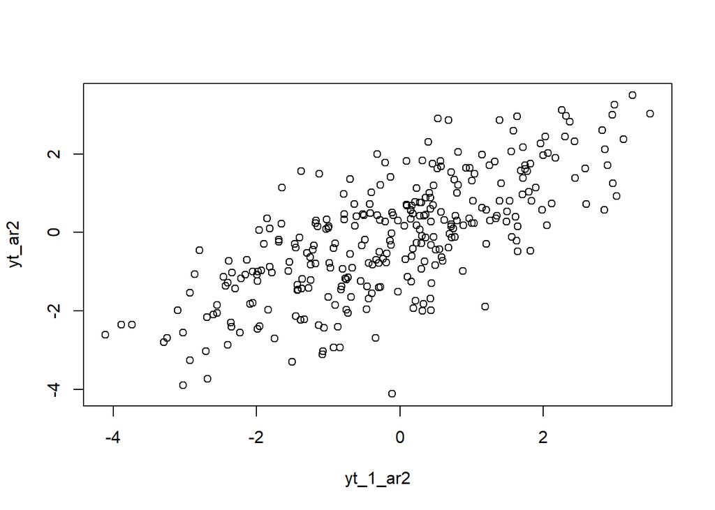

```r
plot(y=yt_ar2,x=yt_1_ar2)
```

Berdasarkan scatterplot tersebut, terlihat bahwa terdapat hubungan positif antara $Y_t$ dengan $Y_{t-1}$. Hal ini sesuai dengan teori yang ada

```r
cor(yt_ar2,yt_1_ar2)
```

```
## [1] 0.7190196
```

### Korelasi antara $Y_t$ dengan $Y_{t-2}$

```r
#Yt
yt_ar2.2 <- ar2[-c(1,2)]
yt_ar2.2
```

```
##   [1]  0.27458346  0.76194543  1.34291904  0.36116707  0.45386737  1.74956435
##   [7]  1.71823474  2.17519003  1.89971879  1.14398950  1.98451529  0.58085631
##  [13] -0.62889318  0.16363358  0.67721866  2.85651456  0.57868024  0.52214328
##  [19]  1.63110692 -0.20837069  1.78154476  1.55710423  2.06915693  2.02959136
##  [25]  2.44780882  1.38933951  2.86186911  2.11799044  0.74282697  0.09604426
##  [31]  0.71675138  1.53456356  0.80000626  1.00551742  0.23508840 -0.27055175
##  [37] -1.38487794 -2.23434122 -2.55449493 -2.05690894 -0.99706591 -1.65017904
##  [43]  0.21699140 -1.74675349 -2.70689650 -3.02974857 -2.55313069 -1.84241324
##  [49] -1.97646227 -0.99670086  0.10946371 -1.12665830  1.49883790  0.52727034
##  [55]  2.89843828  1.70893657  0.96857656  0.35653170 -0.12456105 -0.31331461
##  [61]  0.43309546  0.28151207  0.07571598 -0.68186836 -1.64394015  1.14571630
##  [67]  0.62292455  0.31652953  1.83473863  0.81059577  2.05688992  0.18850850
##  [73] -1.93185497 -0.96825153 -0.90015343 -1.85180695  0.35940435  0.88844947
##  [79]  0.18133223  0.47365132  1.19447968 -1.89543774 -0.29275010 -1.39881945
##  [85] -0.13438300 -0.20812267  0.27512639  0.42966537  0.88168497 -0.98157753
```

[output cut: 35 more lines]

```r
#Yt-2
yt_2_ar2 <- ar2[-c(299,300)]
yt_2_ar2
```

```
##   [1]  1.04557460  1.49228682  0.27458346  0.76194543  1.34291904  0.36116707
##   [7]  0.45386737  1.74956435  1.71823474  2.17519003  1.89971879  1.14398950
##  [13]  1.98451529  0.58085631 -0.62889318  0.16363358  0.67721866  2.85651456
##  [19]  0.57868024  0.52214328  1.63110692 -0.20837069  1.78154476  1.55710423
##  [25]  2.06915693  2.02959136  2.44780882  1.38933951  2.86186911  2.11799044
##  [31]  0.74282697  0.09604426  0.71675138  1.53456356  0.80000626  1.00551742
##  [37]  0.23508840 -0.27055175 -1.38487794 -2.23434122 -2.55449493 -2.05690894
##  [43] -0.99706591 -1.65017904  0.21699140 -1.74675349 -2.70689650 -3.02974857
##  [49] -2.55313069 -1.84241324 -1.97646227 -0.99670086  0.10946371 -1.12665830
##  [55]  1.49883790  0.52727034  2.89843828  1.70893657  0.96857656  0.35653170
##  [61] -0.12456105 -0.31331461  0.43309546  0.28151207  0.07571598 -0.68186836
##  [67] -1.64394015  1.14571630  0.62292455  0.31652953  1.83473863  0.81059577
##  [73]  2.05688992  0.18850850 -1.93185497 -0.96825153 -0.90015343 -1.85180695
##  [79]  0.35940435  0.88844947  0.18133223  0.47365132  1.19447968 -1.89543774
##  [85] -0.29275010 -1.39881945 -0.13438300 -0.20812267  0.27512639  0.42966537
```

[output cut: 35 more lines]

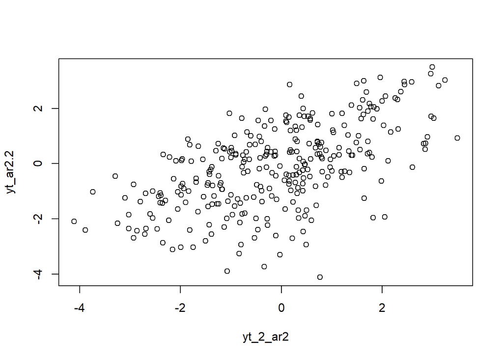

```r
plot(y=yt_ar2.2,x=yt_2_ar2)
```

Berdasarkan scatterplot tersebut, terlihat bahwa terdapat hubungan positif antara $Y_t$ dengan $Y_{t-2}$. Hal ini sesuai dengan teori yang ada

```r
cor(yt_ar2.2,yt_2_ar2)
```

```
## [1] 0.5823772
```

### Korelasi antara $Y_t$ dengan $Y_{t-3}$

```r
#Yt
yt_ar2.3 <- ar2[-c(1,2,3)]
yt_ar2.3
```

```
##   [1]  0.76194543  1.34291904  0.36116707  0.45386737  1.74956435  1.71823474
##   [7]  2.17519003  1.89971879  1.14398950  1.98451529  0.58085631 -0.62889318
##  [13]  0.16363358  0.67721866  2.85651456  0.57868024  0.52214328  1.63110692
##  [19] -0.20837069  1.78154476  1.55710423  2.06915693  2.02959136  2.44780882
##  [25]  1.38933951  2.86186911  2.11799044  0.74282697  0.09604426  0.71675138
##  [31]  1.53456356  0.80000626  1.00551742  0.23508840 -0.27055175 -1.38487794
##  [37] -2.23434122 -2.55449493 -2.05690894 -0.99706591 -1.65017904  0.21699140
##  [43] -1.74675349 -2.70689650 -3.02974857 -2.55313069 -1.84241324 -1.97646227
##  [49] -0.99670086  0.10946371 -1.12665830  1.49883790  0.52727034  2.89843828
##  [55]  1.70893657  0.96857656  0.35653170 -0.12456105 -0.31331461  0.43309546
##  [61]  0.28151207  0.07571598 -0.68186836 -1.64394015  1.14571630  0.62292455
##  [67]  0.31652953  1.83473863  0.81059577  2.05688992  0.18850850 -1.93185497
##  [73] -0.96825153 -0.90015343 -1.85180695  0.35940435  0.88844947  0.18133223
##  [79]  0.47365132  1.19447968 -1.89543774 -0.29275010 -1.39881945 -0.13438300
##  [85] -0.20812267  0.27512639  0.42966537  0.88168497 -0.98157753 -0.77418048
```

[output cut: 35 more lines]

```r
#Yt-2
yt_3_ar2 <- ar2[-c(289,299,300)]
yt_3_ar2
```

```
##   [1]  1.04557460  1.49228682  0.27458346  0.76194543  1.34291904  0.36116707
##   [7]  0.45386737  1.74956435  1.71823474  2.17519003  1.89971879  1.14398950
##  [13]  1.98451529  0.58085631 -0.62889318  0.16363358  0.67721866  2.85651456
##  [19]  0.57868024  0.52214328  1.63110692 -0.20837069  1.78154476  1.55710423
##  [25]  2.06915693  2.02959136  2.44780882  1.38933951  2.86186911  2.11799044
##  [31]  0.74282697  0.09604426  0.71675138  1.53456356  0.80000626  1.00551742
##  [37]  0.23508840 -0.27055175 -1.38487794 -2.23434122 -2.55449493 -2.05690894
##  [43] -0.99706591 -1.65017904  0.21699140 -1.74675349 -2.70689650 -3.02974857
##  [49] -2.55313069 -1.84241324 -1.97646227 -0.99670086  0.10946371 -1.12665830
##  [55]  1.49883790  0.52727034  2.89843828  1.70893657  0.96857656  0.35653170
##  [61] -0.12456105 -0.31331461  0.43309546  0.28151207  0.07571598 -0.68186836
##  [67] -1.64394015  1.14571630  0.62292455  0.31652953  1.83473863  0.81059577
##  [73]  2.05688992  0.18850850 -1.93185497 -0.96825153 -0.90015343 -1.85180695
##  [79]  0.35940435  0.88844947  0.18133223  0.47365132  1.19447968 -1.89543774
##  [85] -0.29275010 -1.39881945 -0.13438300 -0.20812267  0.27512639  0.42966537
```

[output cut: 35 more lines]

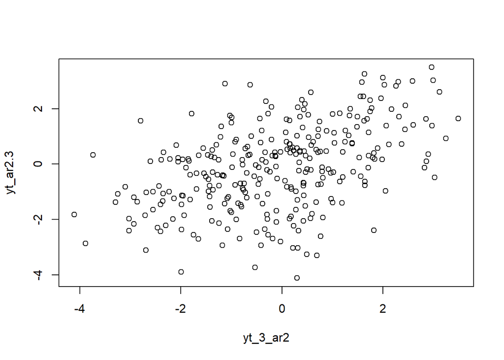

```r
plot(y=yt_ar2.3,x=yt_3_ar2)
```

```r
cor(yt_ar2.3,yt_3_ar2)
```

```
## [1] 0.4605126
```

### Perbandingan korelasi $Yt_t$ dengan $Y_{t-1}$, $Yt_t$ dengan $Y_{t-2}$, & $Yt_t$ dengan $Y_{t-3}$

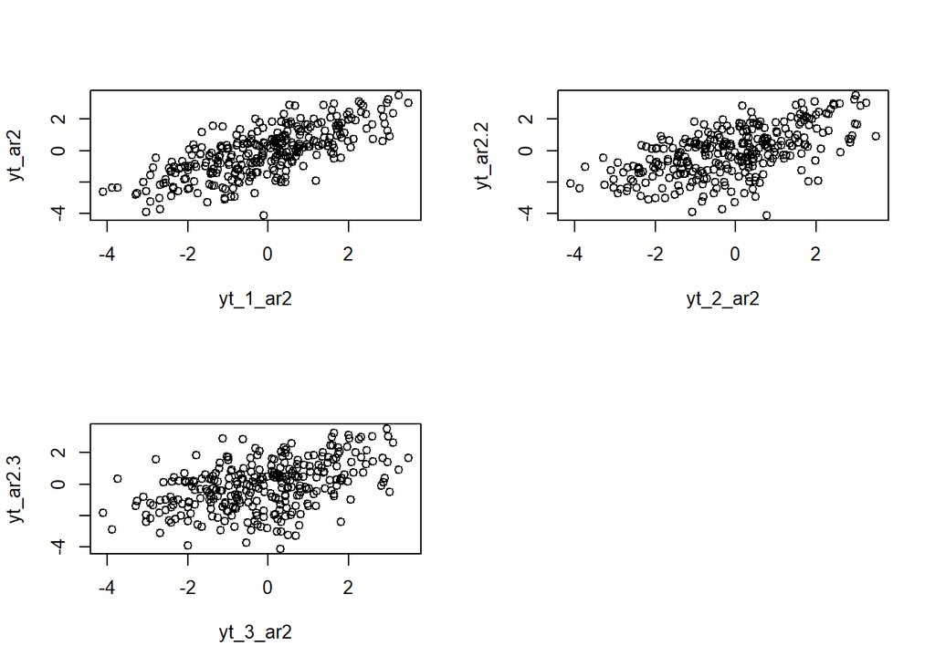

```r
par(mfrow=c(2,2))
plot(y=yt_ar2,x=yt_1_ar2)
plot(y=yt_ar2.2,x=yt_2_ar2)
plot(y=yt_ar2.3,x=yt_3_ar2)
```

## Pembangkitan Proses ARMA(2,2)

### Cara Manual

```r
set.seed(015)
n = length(wn)
phi1 = 0.6
phi2 = 0.4
theta1 = 0.5
theta2 = 0.2

y.arma=c(1:n)
for (i in 3:n) {y.arma[i] <- phi1 * y.arma[i-1] + phi2 * y.arma[i-2] + theta1 * wn[i-1] + theta2 * wn[i-2] + wn[i]}
```

### Fungsi arima.sim

```r
set.seed(015)
arma22 <- arima.sim(list(order=c(2,0,2), ar = c(0.5,0.2), ma = c(0.5,0.2)), n=300)
arma22
```

```
## Time Series:
## Start = 1
## End = 300
## Frequency = 1
##   [1]  1.228456447  1.196638412  1.778003319  1.184401889  0.902566796
##   [6]  2.048374738  2.683518454  3.384012962  3.330802710  2.528766419
##  [11]  2.936361946  1.801841835  0.058384657 -0.034682438  0.633225793
##  [16]  3.227826955  2.142363219  1.382772566  2.007904130  0.711603440
##  [21]  2.003574707  2.406197824  3.204014451  3.375587969  3.876433825
##  [26]  3.019160623  4.046099435  3.826791988  2.374195315  0.891055299
##  [31]  0.913338502  1.912147799  1.710638085  1.712433084  0.897848223
##  [36]  0.048095829 -1.473136216 -2.980890605 -3.948641176 -3.781024685
##  [41] -2.536419397 -2.560093810 -0.807511321 -1.968293613 -3.536874974
##  [46] -4.732547527 -4.609384283 -3.724928305 -3.408295034 -2.353414651
##  [51] -0.784179179 -1.271266620  0.957401489  1.051357630  3.461841028
```

[output cut: 49 more lines]

## Karakteristik ARMA(2,2)

### Plot Time Series

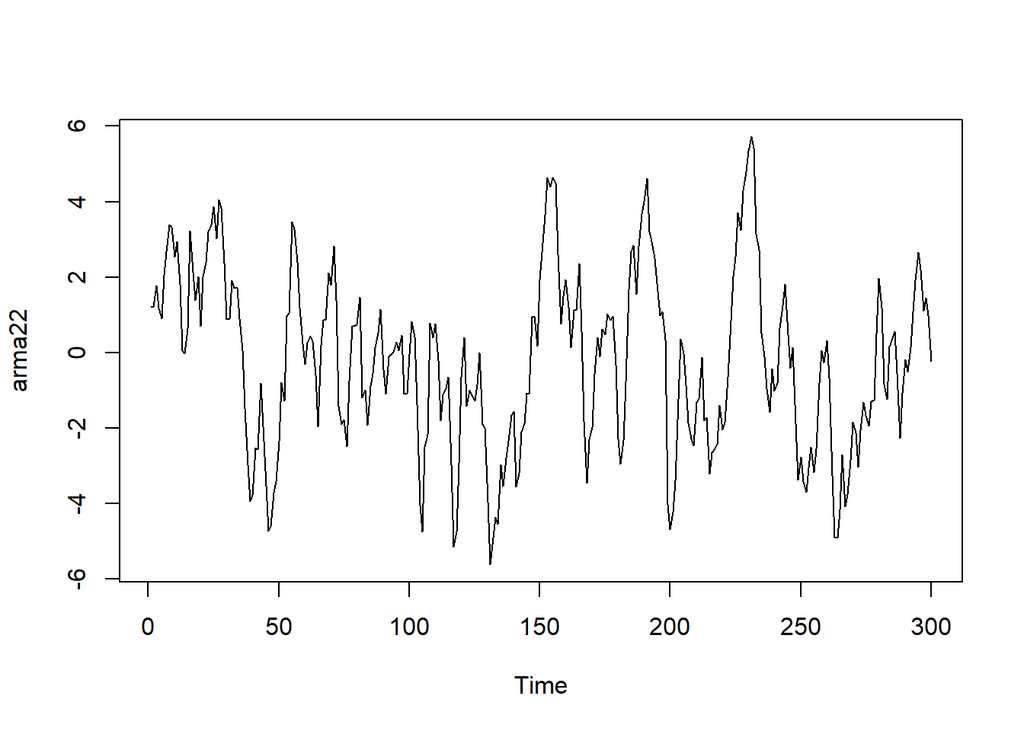

```r
ts.plot(arma22)
```

Berdasarkan plot time series tersebut, terlihat bahwa model ARMA(2,2) cenderung stasioner dalam rataan

### Plot ACF

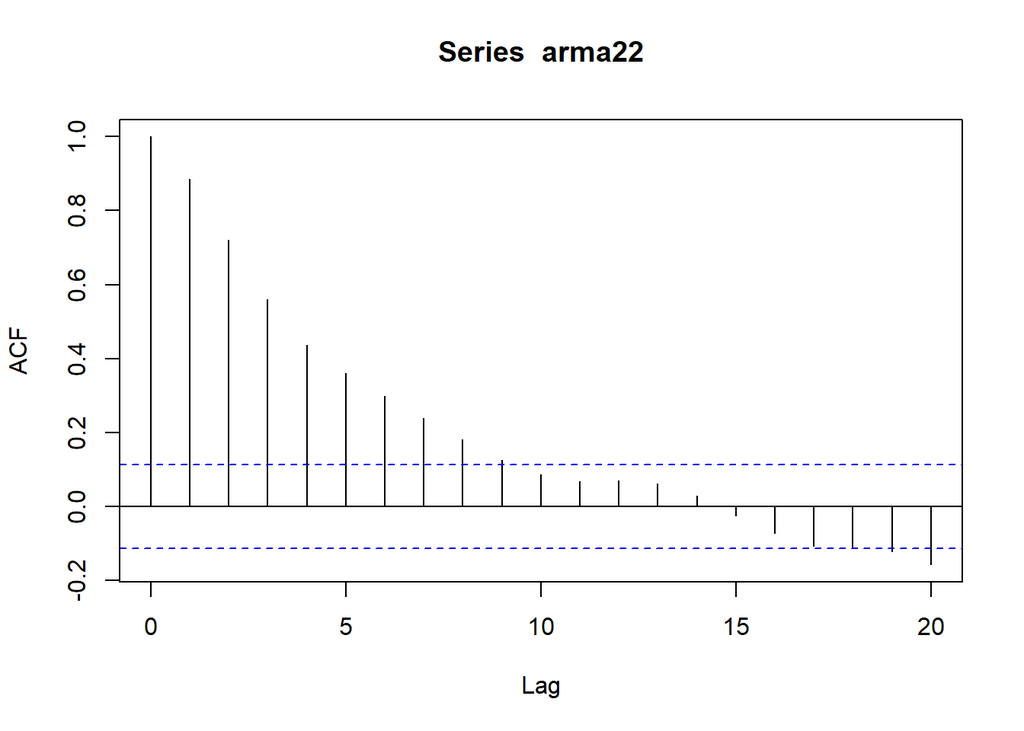

```r
acf(arma22,lag.max = 20)
```

Berdasarkan plot ACF tersebut, terlihat bahwa model ARMA(2,2) hasil simulasi memiliki plot ACF yang *tails off*, sesuai dengan teori yang ada

### Plot PACF

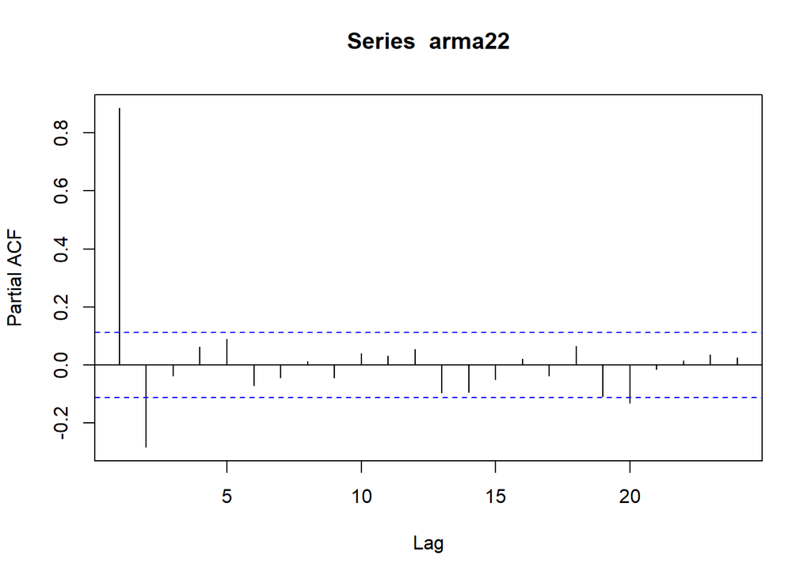

```r
pacf(arma22)
```

Berdasarkan plot PACF tersebut, terlihat bahwa model ARMA(2,2) hasil simulasi memiliki plot PACF yang *tails off*, sesuai dengan teori

### Plot EACF

```r
TSA::eacf(arma22)
```

```
## AR/MA
##   0 1 2 3 4 5 6 7 8 9 10 11 12 13
## 0 x x x x x x x x x o o  o  o  o
## 1 x x o x o o o o o o o  o  o  o
## 2 x x o x o o o o o o o  o  o  o
## 3 x x x o o o o o o o o  o  o  o
## 4 x x x o o o o o o o o  o  o  o
## 5 x x x o o o o o o o o  o  o  o
## 6 x x x x o o o o o o o  o  o  o
## 7 x x o x x o o o o o o  o  o  o
```

## Scatterplot Antar Peubah Lag

### Korelasi antara $Y_t$ dengan $Y_{t-1}$

```r
#Yt
yt_arma22 <- arma22[-1]
yt_arma22
```

```
##   [1]  1.196638412  1.778003319  1.184401889  0.902566796  2.048374738
##   [6]  2.683518454  3.384012962  3.330802710  2.528766419  2.936361946
##  [11]  1.801841835  0.058384657 -0.034682438  0.633225793  3.227826955
##  [16]  2.142363219  1.382772566  2.007904130  0.711603440  2.003574707
##  [21]  2.406197824  3.204014451  3.375587969  3.876433825  3.019160623
##  [26]  4.046099435  3.826791988  2.374195315  0.891055299  0.913338502
##  [31]  1.912147799  1.710638085  1.712433084  0.897848223  0.048095829
##  [36] -1.473136216 -2.980890605 -3.948641176 -3.781024685 -2.536419397
##  [41] -2.560093810 -0.807511321 -1.968293613 -3.536874974 -4.732547527
##  [46] -4.609384283 -3.724928305 -3.408295034 -2.353414651 -0.784179179
##  [51] -1.271266620  0.957401489  1.051357630  3.461841028  3.263609774
##  [56]  2.402732498  1.182607292  0.247420116 -0.304288795  0.251525940
##  [61]  0.435396874  0.303091103 -0.587707960 -1.969731132  0.187372556
##  [66]  0.866994675  0.857135065  2.117588309  1.791270988  2.829135525
##  [71]  1.379072615 -1.426222739 -1.896477315 -1.770650185 -2.495533966
```

[output cut: 45 more lines]

```r
#Yt-1
yt_1_arma22 <- arma22[-300]
yt_1_arma22
```

```
##   [1]  1.228456447  1.196638412  1.778003319  1.184401889  0.902566796
##   [6]  2.048374738  2.683518454  3.384012962  3.330802710  2.528766419
##  [11]  2.936361946  1.801841835  0.058384657 -0.034682438  0.633225793
##  [16]  3.227826955  2.142363219  1.382772566  2.007904130  0.711603440
##  [21]  2.003574707  2.406197824  3.204014451  3.375587969  3.876433825
##  [26]  3.019160623  4.046099435  3.826791988  2.374195315  0.891055299
##  [31]  0.913338502  1.912147799  1.710638085  1.712433084  0.897848223
##  [36]  0.048095829 -1.473136216 -2.980890605 -3.948641176 -3.781024685
##  [41] -2.536419397 -2.560093810 -0.807511321 -1.968293613 -3.536874974
##  [46] -4.732547527 -4.609384283 -3.724928305 -3.408295034 -2.353414651
##  [51] -0.784179179 -1.271266620  0.957401489  1.051357630  3.461841028
##  [56]  3.263609774  2.402732498  1.182607292  0.247420116 -0.304288795
##  [61]  0.251525940  0.435396874  0.303091103 -0.587707960 -1.969731132
##  [66]  0.187372556  0.866994675  0.857135065  2.117588309  1.791270988
##  [71]  2.829135525  1.379072615 -1.426222739 -1.896477315 -1.770650185
```

[output cut: 45 more lines]

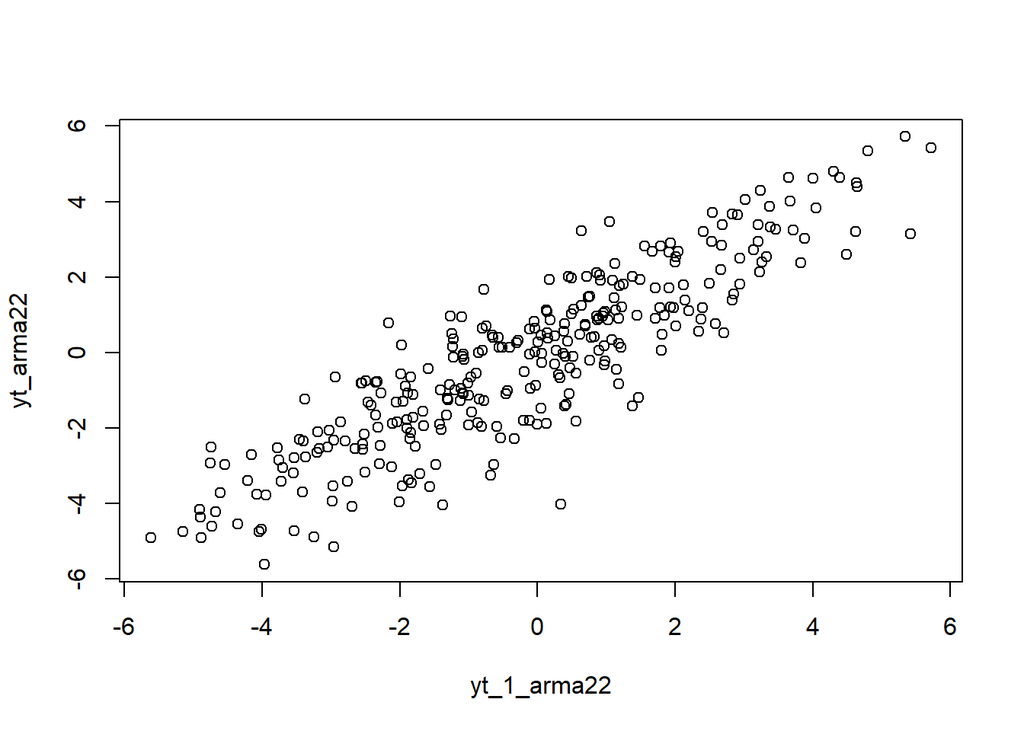

```r
plot(y=yt_arma22,x=yt_1_arma22)
```

Berdasarkan scatterplot tersebut, terlihat bahwa terdapat hubungan positif antara $Y_t$ dengan $Y_{t-1}$. Hal ini sesuai dengan teori yang ada

```r
cor(yt_arma22,yt_1_arma22)
```

```
## [1] 0.8852292
```

### Korelasi antara $Y_t$ dengan $Y_{t-2}$

```r
#Yt
yt_arma22.2 <- arma22[-c(1,2)]
yt_arma22.2
```

```
##   [1]  1.778003319  1.184401889  0.902566796  2.048374738  2.683518454
##   [6]  3.384012962  3.330802710  2.528766419  2.936361946  1.801841835
##  [11]  0.058384657 -0.034682438  0.633225793  3.227826955  2.142363219
##  [16]  1.382772566  2.007904130  0.711603440  2.003574707  2.406197824
##  [21]  3.204014451  3.375587969  3.876433825  3.019160623  4.046099435
##  [26]  3.826791988  2.374195315  0.891055299  0.913338502  1.912147799
##  [31]  1.710638085  1.712433084  0.897848223  0.048095829 -1.473136216
##  [36] -2.980890605 -3.948641176 -3.781024685 -2.536419397 -2.560093810
##  [41] -0.807511321 -1.968293613 -3.536874974 -4.732547527 -4.609384283
##  [46] -3.724928305 -3.408295034 -2.353414651 -0.784179179 -1.271266620
##  [51]  0.957401489  1.051357630  3.461841028  3.263609774  2.402732498
##  [56]  1.182607292  0.247420116 -0.304288795  0.251525940  0.435396874
##  [61]  0.303091103 -0.587707960 -1.969731132  0.187372556  0.866994675
##  [66]  0.857135065  2.117588309  1.791270988  2.829135525  1.379072615
##  [71] -1.426222739 -1.896477315 -1.770650185 -2.495533966 -0.746529808
```

[output cut: 45 more lines]

```r
#Yt-2
yt_2_arma22 <- arma22[-c(299,300)]
yt_2_arma22
```

```
##   [1]  1.228456447  1.196638412  1.778003319  1.184401889  0.902566796
##   [6]  2.048374738  2.683518454  3.384012962  3.330802710  2.528766419
##  [11]  2.936361946  1.801841835  0.058384657 -0.034682438  0.633225793
##  [16]  3.227826955  2.142363219  1.382772566  2.007904130  0.711603440
##  [21]  2.003574707  2.406197824  3.204014451  3.375587969  3.876433825
##  [26]  3.019160623  4.046099435  3.826791988  2.374195315  0.891055299
##  [31]  0.913338502  1.912147799  1.710638085  1.712433084  0.897848223
##  [36]  0.048095829 -1.473136216 -2.980890605 -3.948641176 -3.781024685
##  [41] -2.536419397 -2.560093810 -0.807511321 -1.968293613 -3.536874974
##  [46] -4.732547527 -4.609384283 -3.724928305 -3.408295034 -2.353414651
##  [51] -0.784179179 -1.271266620  0.957401489  1.051357630  3.461841028
##  [56]  3.263609774  2.402732498  1.182607292  0.247420116 -0.304288795
##  [61]  0.251525940  0.435396874  0.303091103 -0.587707960 -1.969731132
##  [66]  0.187372556  0.866994675  0.857135065  2.117588309  1.791270988
##  [71]  2.829135525  1.379072615 -1.426222739 -1.896477315 -1.770650185
```

[output cut: 45 more lines]

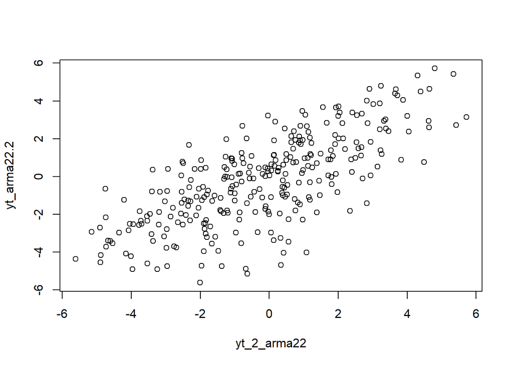

```r
plot(y=yt_arma22.2,x=yt_2_arma22)
```

Berdasarkan scatterplot tersebut, terlihat bahwa terdapat hubungan positif antara $Y_t$ dengan $Y_{t-2}$. Hal ini sesuai dengan teori yang ada

```r
cor(yt_arma22.2,yt_2_arma22)
```

```
## [1] 0.722292
```

### Korelasi antara $Y_t$ dengan $Y_{t-3}$

```r
#Yt
yt_arma22.3 <- arma22[-c(1,2,3)]
yt_arma22.3
```

```
##   [1]  1.184401889  0.902566796  2.048374738  2.683518454  3.384012962
##   [6]  3.330802710  2.528766419  2.936361946  1.801841835  0.058384657
##  [11] -0.034682438  0.633225793  3.227826955  2.142363219  1.382772566
##  [16]  2.007904130  0.711603440  2.003574707  2.406197824  3.204014451
##  [21]  3.375587969  3.876433825  3.019160623  4.046099435  3.826791988
##  [26]  2.374195315  0.891055299  0.913338502  1.912147799  1.710638085
##  [31]  1.712433084  0.897848223  0.048095829 -1.473136216 -2.980890605
##  [36] -3.948641176 -3.781024685 -2.536419397 -2.560093810 -0.807511321
##  [41] -1.968293613 -3.536874974 -4.732547527 -4.609384283 -3.724928305
##  [46] -3.408295034 -2.353414651 -0.784179179 -1.271266620  0.957401489
##  [51]  1.051357630  3.461841028  3.263609774  2.402732498  1.182607292
##  [56]  0.247420116 -0.304288795  0.251525940  0.435396874  0.303091103
##  [61] -0.587707960 -1.969731132  0.187372556  0.866994675  0.857135065
##  [66]  2.117588309  1.791270988  2.829135525  1.379072615 -1.426222739
##  [71] -1.896477315 -1.770650185 -2.495533966 -0.746529808  0.697790255
```

[output cut: 45 more lines]

```r
#Yt-2
yt_3_arma22 <- arma22[-c(289,299,300)]
yt_3_arma22
```

```
##   [1]  1.228456447  1.196638412  1.778003319  1.184401889  0.902566796
##   [6]  2.048374738  2.683518454  3.384012962  3.330802710  2.528766419
##  [11]  2.936361946  1.801841835  0.058384657 -0.034682438  0.633225793
##  [16]  3.227826955  2.142363219  1.382772566  2.007904130  0.711603440
##  [21]  2.003574707  2.406197824  3.204014451  3.375587969  3.876433825
##  [26]  3.019160623  4.046099435  3.826791988  2.374195315  0.891055299
##  [31]  0.913338502  1.912147799  1.710638085  1.712433084  0.897848223
##  [36]  0.048095829 -1.473136216 -2.980890605 -3.948641176 -3.781024685
##  [41] -2.536419397 -2.560093810 -0.807511321 -1.968293613 -3.536874974
##  [46] -4.732547527 -4.609384283 -3.724928305 -3.408295034 -2.353414651
##  [51] -0.784179179 -1.271266620  0.957401489  1.051357630  3.461841028
##  [56]  3.263609774  2.402732498  1.182607292  0.247420116 -0.304288795
##  [61]  0.251525940  0.435396874  0.303091103 -0.587707960 -1.969731132
##  [66]  0.187372556  0.866994675  0.857135065  2.117588309  1.791270988
##  [71]  2.829135525  1.379072615 -1.426222739 -1.896477315 -1.770650185
```

[output cut: 45 more lines]

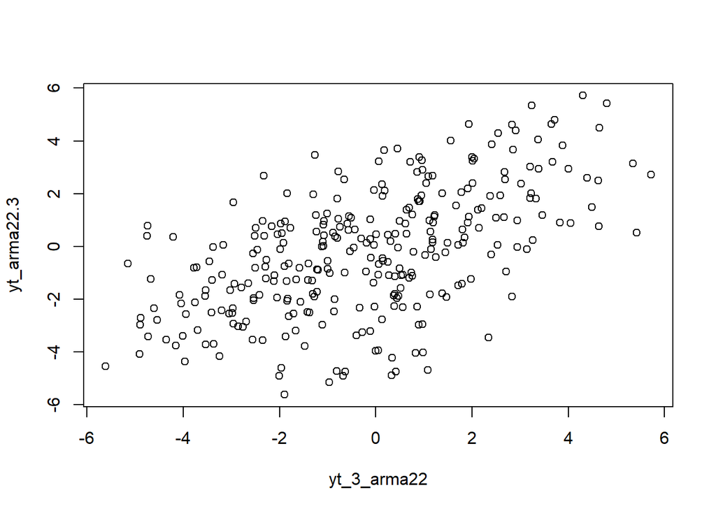

```r
plot(y=yt_arma22.3,x=yt_3_arma22)
```

Berdasarkan scatterplot tersebut, terlihat bahwa masih terdapat kecenderungan hubungan positif antara $Y_t$ dengan $Y_{t-3}$. Hal ini sesuai dengan teori yang ada

```r
cor(yt_arma22.3,yt_3_arma22)
```

```
## [1] 0.5654948
```

### Perbandingan korelasi $Yt_t$ dengan $Y_{t-1}$, $Yt_t$ dengan $Y_{t-2}$, & $Yt_t$ dengan $Y_{t-3}$

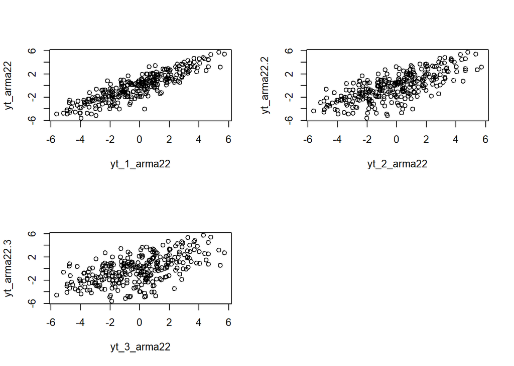

```r
par(mfrow=c(2,2))
plot(y=yt_arma22,x=yt_1_arma22)
plot(y=yt_arma22.2,x=yt_2_arma22)
plot(y=yt_arma22.3,x=yt_3_arma22)
```